# reporte asuich

David Flores

2026-06-15

## Reporte de base de datos de *Valores nutricionales*

```r
datos<- read.table("C:/Users/100032608/Downloads/NivelesNutritivos.txt", header=T)
datos
```

```
##    Region Variedad NivelesNutritivos
## 1       A        W               6.9
## 2       A        W              11.8
## 3       A        W               6.2
## 4       A        W               9.2
## 5       A        W               9.2
## 6       A        W               6.2
## 7       A        X              11.0
## 8       A        X               7.8
## 9       A        X               7.3
## 10      A        X               9.1
## 11      A        X               7.9
## 12      A        X               6.9
## 13      A        Y              13.1
## 14      A        Y              12.1
```

[output cut: 58 more lines]

Primero se carga la base de datos, lo hice copiando desde la ruta de acceso a través de las descargas  
Todo eso se asignó a un objeto llamado *datos* y posteriormente se cargó para visualizar la base de datos.

Posteriormente se empezó con el análisis con métodos paramétricos

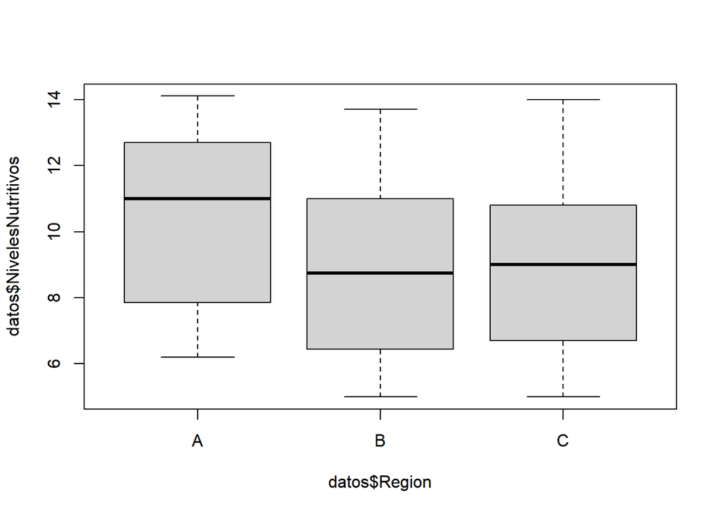

```r
boxplot(datos$NivelesNutritivos~datos$Region)
```

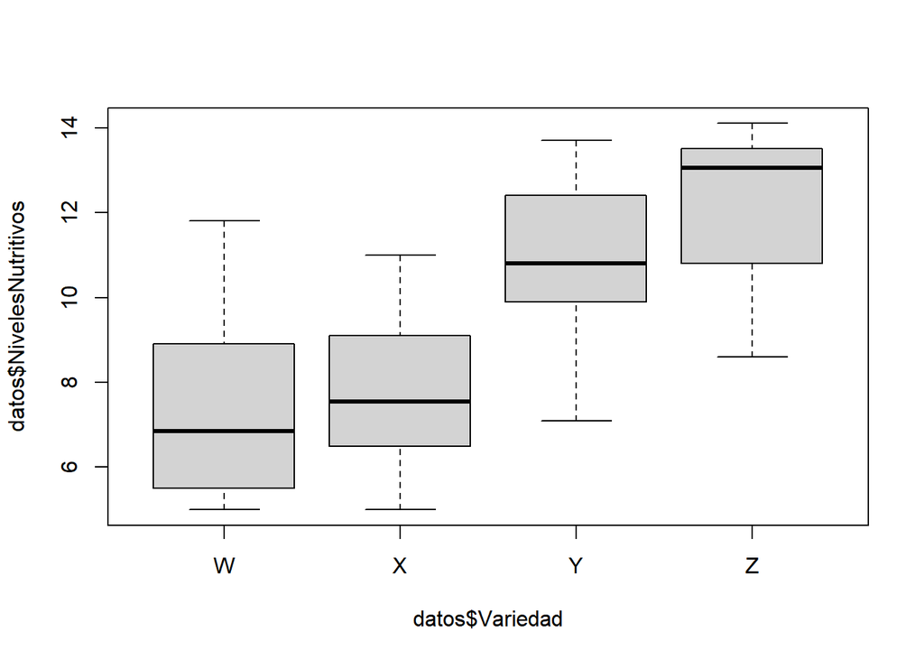

```r
boxplot(datos$NivelesNutritivos~datos$Variedad)
```

```r
mediasRegion <- tapply(datos$NivelesNutritivos, datos$Region, summary)
mediasRegion
```

```
## $A
##    Min. 1st Qu.  Median    Mean 3rd Qu.    Max.
##   6.200   7.875  11.000  10.387  12.550  14.100
##
## $B
##    Min. 1st Qu.  Median    Mean 3rd Qu.    Max.
##   5.000   6.775   8.750   8.908  10.450  13.700
##
## $C
##    Min. 1st Qu.  Median    Mean 3rd Qu.    Max.
##   5.000   6.750   9.000   9.075  10.800  14.000
```

```r
#aquí se ve que la media y la mediana están muy cercanas entre sí, eso quiere decir que las distribuciones están más o menos centradas

mediasVariedad <- tapply(datos$NivelesNutritivos, datos$Variedad, summary)
mediasVariedad
```

```
## $W
##    Min. 1st Qu.  Median    Mean 3rd Qu.    Max.
##   5.000   5.550   6.850   7.167   8.625  11.800
##
## $X
##    Min. 1st Qu.  Median    Mean 3rd Qu.    Max.
##   5.000   6.525   7.550   7.628   8.900  11.000
##
## $Y
##    Min. 1st Qu.  Median    Mean 3rd Qu.    Max.
##   7.100   9.925  10.800  10.806  12.325  13.700
##
## $Z
##    Min. 1st Qu.  Median    Mean 3rd Qu.    Max.
##    8.60   11.05   13.05   12.23   13.50   14.10
```

```r
desviacionregion <-tapply(datos$NivelesNutritivos, datos$Region, sd)
desviacionregion
```

```
##        A        B        C
## 2.624684 2.844815 2.848989
```

```r
desviacionvariedad <-tapply(datos$NivelesNutritivos, datos$Variedad, sd)
desviacionvariedad
```

```
##        W        X        Y        Z
## 1.892400 1.779559 1.987156 1.804506
```

En estos análisis se evaluaron las medidas de tendencia central como la media además de la desviación de los datos, lo que nos arroja esto es que las medias y medianas están cercanas entre si, lo que significa que las distribuciones están más o menos centradas, aspecto que se revela en las gráficas de boxplot mostradas anteriormente.  
Y la desviación estandar aplicada a las variables nos muestra que no hay una gran diferencia en los valores de las mismas por lo que la variabilidad entre estas es poco significativa.